# 図鑑の見せ方 — 分かりやすさで比べ直した結論 (2026-10-13)

回したチーム: 顧客理解・反対役 (1つのAI) / 届け方 / 収益 / 制作 (試作3枚は別のAI) / まとめはクロード。中心の問い「乗り換え路線図は新しい概念すぎて分かりにくいのでは」。

## 結論

1. **本人の見立ては正しい**。路線図は「自分の駅が見つからない」(405駅がスマホ1枚で読めない) のが一番の壁。入口には向かない。サイトの中の全体図に回す
2. **入口は「減りやすい順ランキング」(A)**。2秒で「自分の仕事は何位?」になる。ただし見て完結しやすいので、自分の職種の続きはサイトで
3. **出口 (サイトで見せる形) は「Before/After」(C)**。「AIで減らない作業が 15% → 65%」のひと言で一番伝わる (試作の採点でも分かりやすさ1位)。「移りやすい3つ」(B) は情報が多いので、Cの下の詳しい欄に

## 反対役が止めた点

- **バズは売上ではない**。約70万再生でサイト訪問ほぼ0。バズを増やすより「リンクを押す理由」を作るのが先
- **紹介料が入る条件**: 移る先の職種ごとに、資格講座か転職の案件が1つ結びついていること。今の申請9件 (審査中) では足りない職種がある
- **誇張しない**: 「移れる」とは書かず「作業が近い」。資格・期間・年収が下がる可能性を1行ずつ。作業の近さは弱い (0.09〜0.13) 例が多い
- **作れない職種がある**: 一般事務は、危険度の低い職種との作業の近さが最大0.054で、移り先カードが作れなかった。全職種に出せる型ではない
- 「あと何年」は元データに年数が無いので使わない (帯と数字で示す)

## 試作 (外に出していない)

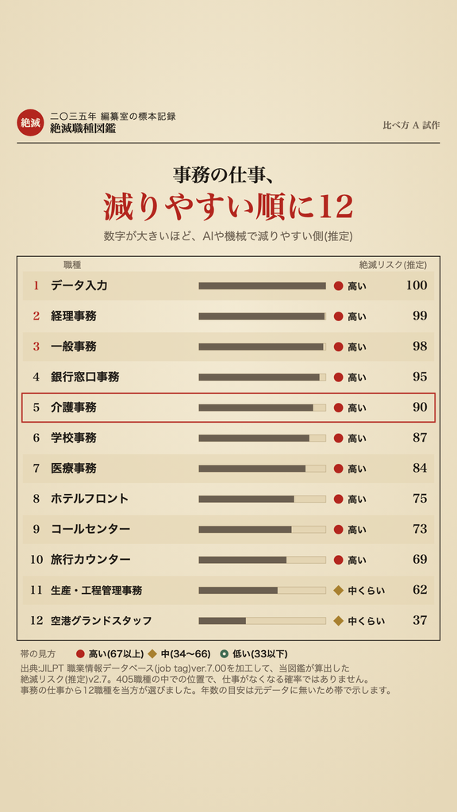

A 減りやすい順ランキング (入口)

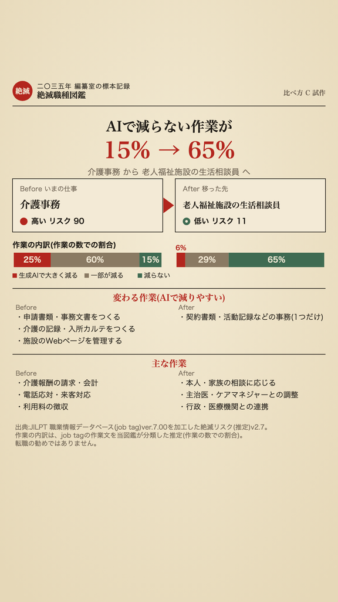

C Before/After (出口)

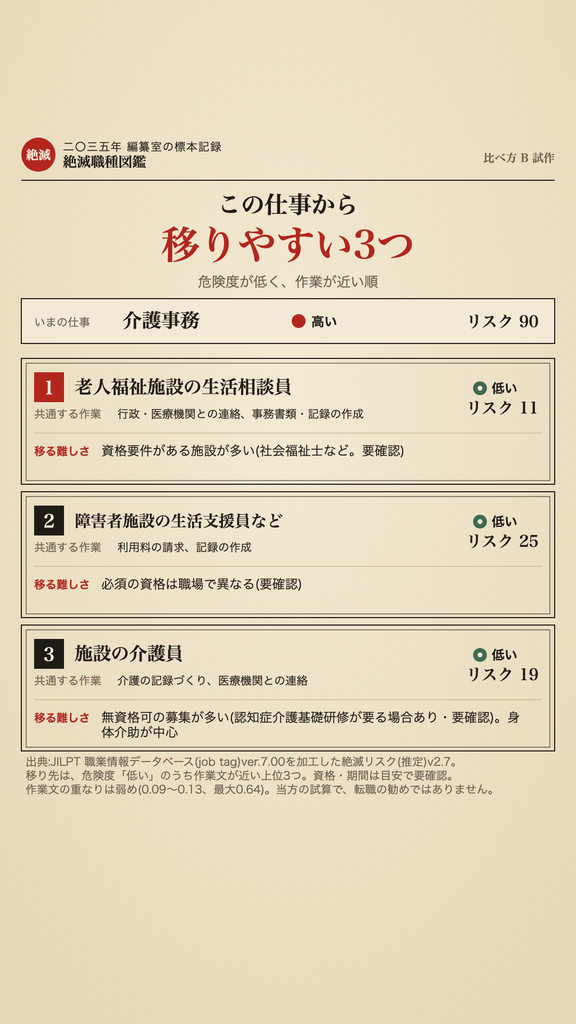

B 移りやすい3つ (詳しい欄)

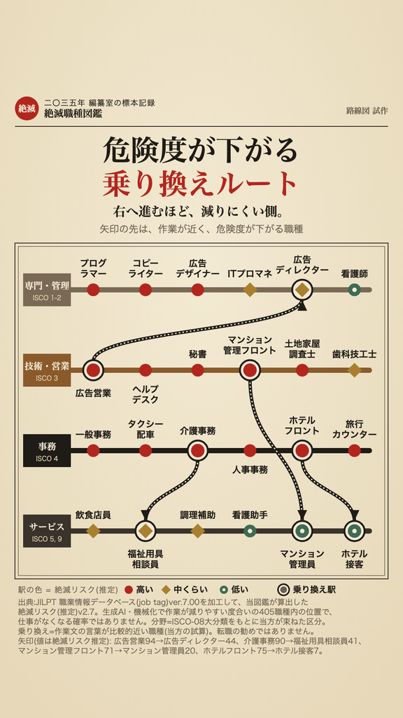

路線図 (サイト内の全体図に回す)

## 小さな比べ方 (出すのは承認の後)

- 何を: 同じ職業で A (ランキング) と C (Before/After) の2枚。色・長さ・時間帯をそろえ、違いは中身だけ
- どこで: Instagram と X の静止画。プロフィールのリンク先は同じ職種ページ
- 職業: 3つ (例: 介護事務・経理事務・コールセンター) × 2枚 = 6本、同じ日の同じ時間に
- 期間: 7日
- 決める数字: ①リンクを押した割合 (主) ②保存+シェア ③サイトで30秒以上見た割合と紹介のクリック。差が2倍未満なら別の3職で再試験
- 先にやること: 移る先の職種に紹介の案件を結びつける (無いと成約まで見られない)

## 次に決めること (1問)

この形で進める？

1. A を入口・C を出口で、比べる試しの準備まで進める (おすすめ)
2. 路線図も残して3つで比べる
3. もう一度考え直す